# Differential Expression Analysis

This notebook shows the differential expression analysis for the experiment normal_vs_sugarfed.

There are different graphs that represent an exploratory analysis of the data, the quality of the results and the list of genes that have a relevant difference in expression bettewn two groups of samples.

### Load libraries

- **edger:** Library to normalize RNA-seq expression data [1].
- **noiseq:** Using noiseq exploratory plots to evaluate the quality of the results [2].
- **biomart:** Interface to biomart databases [3]

```r
library(gplots)
library(edgeR)
library(NOISeq)
library(biomaRt)

# Parameters
expName = params$expName
cpmLimit = params$cpm
pValueLimit = params$pvalue
```

### Load Experimental data

Loading count data from output of *featurecounts* tool.

```r
sampleinfo <- read.csv(paste("setup/", expName, ".tsv", sep=""), sep = " ")
seqdata <- read.delim(paste("count/", expName, "_count.tsv", sep=""), sep = "\t", stringsAsFactors = FALSE, header=TRUE, skip=1)

counts <- seqdata[,(7:ncol(seqdata))]
rownames(counts) <- seqdata[,1]
colnames(counts) <- sampleinfo[,3]

groups <- sampleinfo[,4]

group0numSamples <- sum(sampleinfo[,5]==0)
group1numSamples <- sum(sampleinfo[,5]==1)
sampleinfo
```

```
##                     FastaFile                    BamFile SampleName
## 1   reads/Normal1_mappable.fq   bam/Normal1_mappable.bam    Normal1
## 2   reads/Normal2_mappable.fq   bam/Normal2_mappable.bam    Normal2
## 3 reads/SugarFed1_mappable.fq bam/SugarFed1_mappable.bam  SugarFed1
## 4 reads/SugarFed2_mappable.fq bam/SugarFed2_mappable.bam  SugarFed2
##   SampleGroup Group
## 1      Normal     0
## 2      Normal     0
## 3    SugarFed     1
## 4    SugarFed     1
```

### TMM Normalization (Edger)

```r
# Set up the groups based on the experimental setup.
cond_1 = rep("cond1", group0numSamples)
cond_2 = rep("cond2", group1numSamples)

# Create the groups.
group=c(cond_1, cond_2)

dge <- DGEList(counts=counts, group=group)
dge <- estimateCommonDisp(dge)
dge <- estimateGLMTrendedDisp(dge)
dge <- estimateTagwiseDisp(dge)


# Perform pairwise comparison.
etx <- exactTest(dge)
etp <- topTags(etx, n=100000, sort.by="p.value")

# Generate the output.
edgerCountsFile <- paste("count/", expName, "_count_edger.tsv", sep="")
edgerCounts <- etp$table
write.table(edgerCounts, file=edgerCountsFile, sep="\t", row.name=TRUE, quote=FALSE)

# Get normalized counts and write to a file
scale = dge$samples$lib.size*dge$samples$norm.factors
nc = round(t(t(counts)/scale)*mean(scale))

# Turn it into a dataframe to have proper column names.
dt = data.frame("id"=rownames(nc),nc)

# Save into the normalize data matrix.
normCountsFile <- paste("count/", expName, "_count_norm.tsv", sep="")
normCounts <- dt
write.table(dt, file=normCountsFile, sep="\t", row.name=FALSE, col.names=TRUE, quote=FALSE)
```

# Exploration Analysis

Build the data structure for all the NOISEQ graphs.

```r
vectorbase_gene <- new("Mart", biomart = "vb_gene_mart_1902", vschema = "vb_mart_1902", host = "https://biomart.vectorbase.org/biomart/martservice")
aaegGenes<-useDataset("alvpagwg_eg_gene", vectorbase_gene)

sample_biotype <- getBM(attributes = c("ensembl_gene_id", "gene_biotype"), mart = aaegGenes)
sample_gc_content <- getBM(attributes = c("ensembl_gene_id", "percentage_gene_gc_content"), mart = aaegGenes)
sample_length <- seqdata[,c(1,6)]
sample_chrm_pos <- getBM(attributes = c("ensembl_gene_id", "chromosome_name", "start_position", "end_position"), mart = aaegGenes)
sample_chrm <- sample_chrm_pos[, c(2,3,4)]
rownames(sample_chrm) <- sample_chrm_pos[,1]
sample_factors <- sampleinfo[,c(3,4,5)]
sample_count <- normCounts[, 2:ncol(normCounts)]

noiseq_data <- readData(data=sample_count,length=sample_length, biotype=sample_biotype, gc=sample_gc_content, chromosome=sample_chrm, factors=sample_factors)
```

### Countsbio plots

```r
# Build countbio data
countsbio_data = dat(noiseq_data, factor = NULL, type = "countsbio")
```

```
## [1] "Warning: 6285 features with 0 counts in all samples are to be removed for this analysis."
## [1] "Count distributions are to be computed for:"
## [1] "Normal1"   "Normal2"   "SugarFed1" "SugarFed2"
```

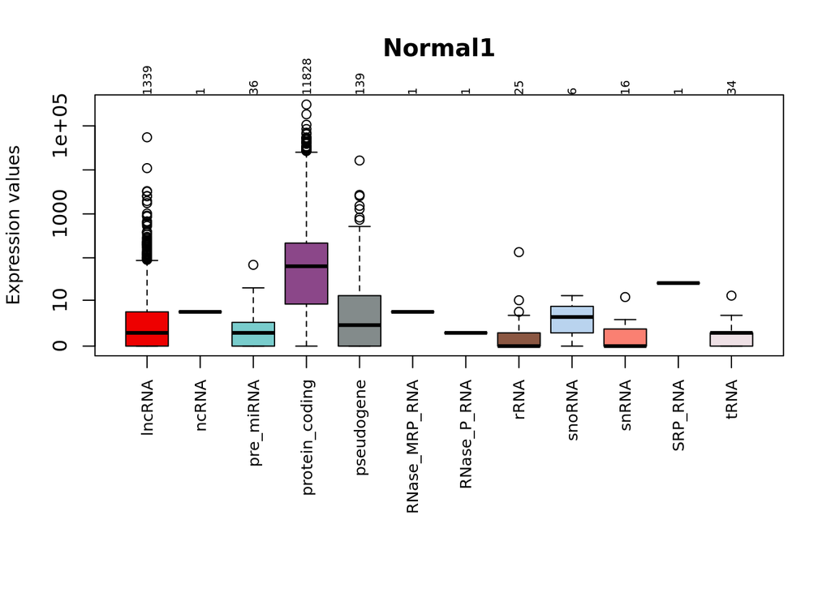

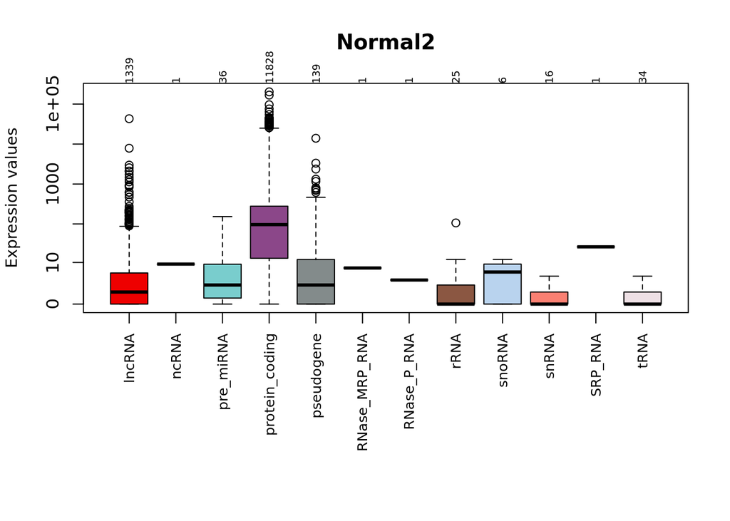

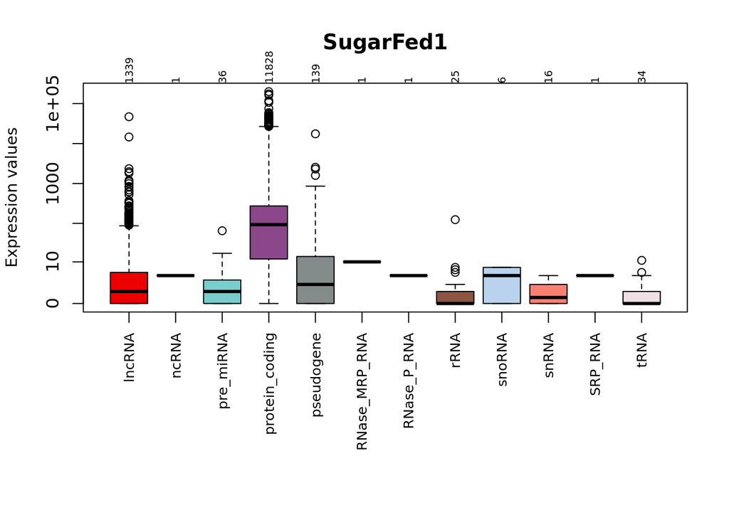

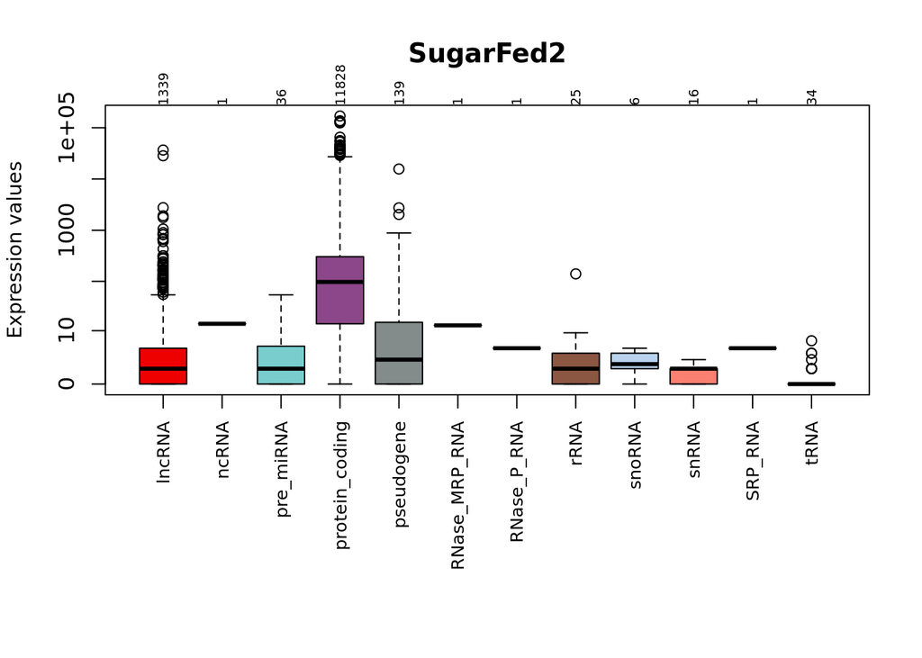

```r
# Count data samples
for( i in 1:nrow(sampleinfo)){
  explo.plot(countsbio_data, toplot = 1, samples = i, plottype = "boxplot")
}
```

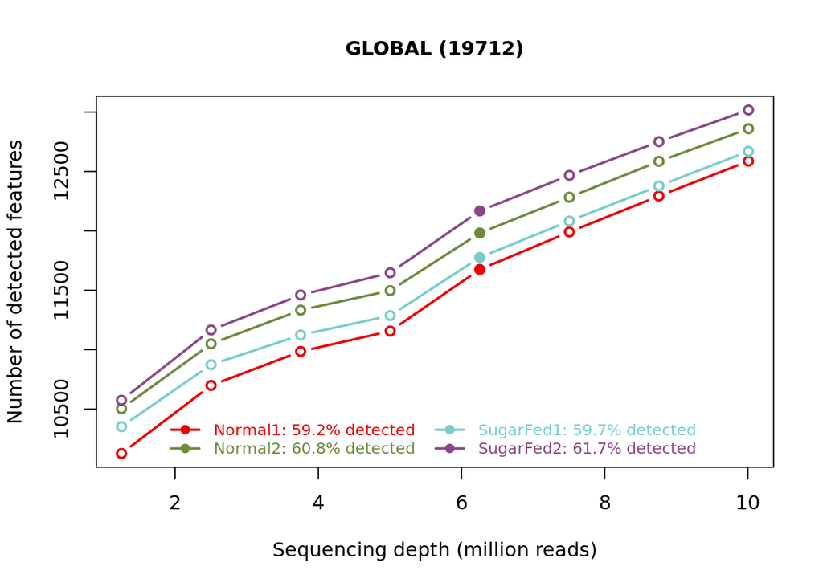

```r
# Saturation plot
saturation_data = dat(noiseq_data, k = 0, ndepth = 7, type = "saturation")
explo.plot(saturation_data, toplot = 1, samples = 1:nrow(sampleinfo), yleftlim = NULL, yrightlim = NULL)
```

### Biodetection plots

The gray bar corresponds to the percentage of each biotypein the genome, the stripped color bar is the proportion detected in oursample, and the solid color bar is the percentage of each biotype withinthe sample. The vertical green line separates the most abundant biotypes from the rest (in the right-hand side, corresponding to the right axis scale).

```r
# data
biodetection_data <- dat(noiseq_data, type = "biodetection")
```

```
## Biotypes detection is to be computed for:
## [1] "Normal1"   "Normal2"   "SugarFed1" "SugarFed2"
```

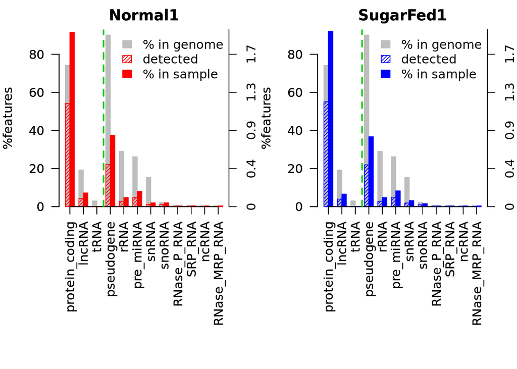

```r
par(mfrow = c(1, 2))
explo.plot(biodetection_data, samples = c(1, 1 + group0numSamples), plottype = "persample")
```

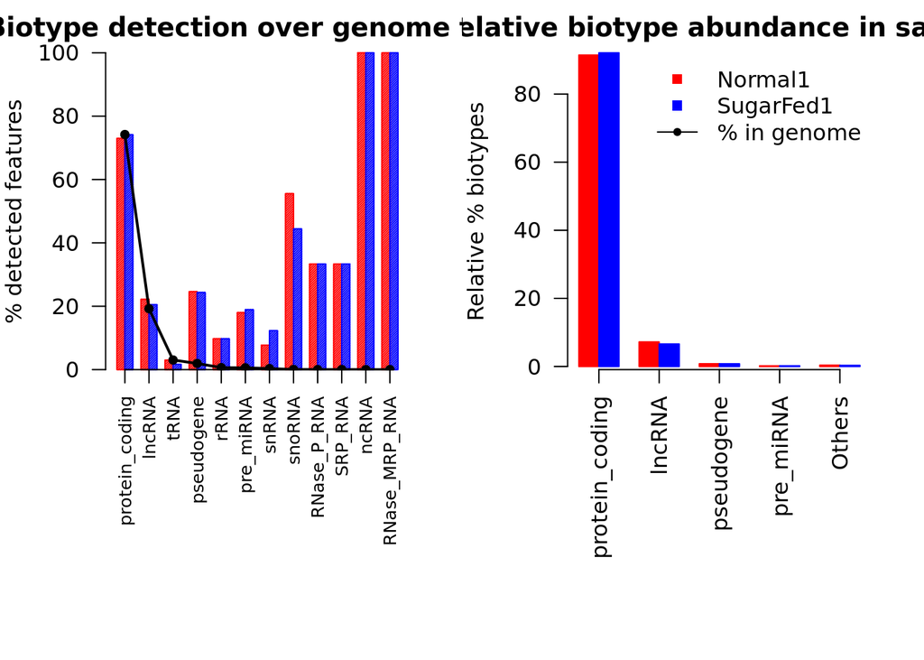

```
## [1] "Percentage of protein_coding biotype in each sample:"
##   Normal1 SugarFed1
##   91.4418   92.1114
## [1] "Confidence interval at 95% for the difference of percentages: Normal1 - SugarFed1"
## [1] -1.2170 -0.1222
## [1] "The percentage of this biotype is significantly DIFFERENT for these two samples (p-value = 0.01632 )."
```

```r
par(mfrow = c(1, 2))
explo.plot(biodetection_data, samples = c(1, 1 + group0numSamples), toplot = "protein_coding", plottype = "comparison")
```

### Sensitivity

The “Sensitivity plot” helps to decide the threshold to remove low-count features by indicating the proportion of such features that are presentin our data.

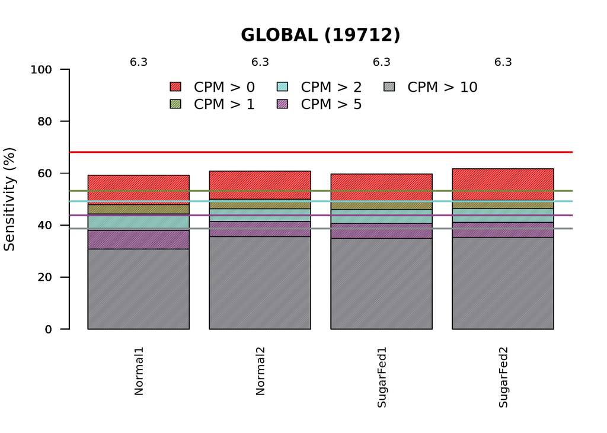

```r
explo.plot(countsbio_data, toplot = 1, samples = NULL, plottype = "barplot")
```

### Length Bias

The “lengthbias” plot describes the relationship between the feature length and the expression values.

```r
lengthbias_data = dat(noiseq_data, factor = "SampleGroup", type = "lengthbias")
```

```
## [1] "Warning: 6285 features with 0 counts in all samples are to be removed for this analysis."
## [1] "Length bias detection information is to be computed for:"
## [1] "Normal"   "SugarFed"
## [1] "Normal"
##
## Call:
## lm(formula = datos[, i] ~ bx)
##
## Residuals:
##     Min      1Q  Median      3Q     Max
## -23.628  -8.927  -0.234   4.492  64.129
##
## Coefficients: (1 not defined because of singularities)
##              Estimate Std. Error t value Pr(>|t|)
## (Intercept)    59.011     17.444   3.383   0.0013 **
## bx1           -51.654     22.105  -2.337   0.0230 *
## bx2             1.853     20.957   0.088   0.9299
## bx3           -53.460     21.363  -2.502   0.0152 *
## bx4            -9.289     21.835  -0.425   0.6721
## bx5           -31.542     25.142  -1.255   0.2148
## bx6           -20.206     33.967  -0.595   0.5543
## bx7           -14.693     68.109  -0.216   0.8300
## bx8           138.207   1559.995   0.089   0.9297
## bx9         -7276.977  51756.405  -0.141   0.8887
## bx10               NA         NA      NA       NA
## ---
## Signif. codes:  0 '***' 0.001 '**' 0.01 '*' 0.05 '.' 0.1 ' ' 1
##
## Residual standard error: 17.44 on 57 degrees of freedom
## Multiple R-squared:  0.1581, Adjusted R-squared:  0.02511
## F-statistic: 1.189 on 9 and 57 DF,  p-value: 0.3198
##
## [1] "SugarFed"
##
## Call:
## lm(formula = datos[, i] ~ bx)
##
## Residuals:
##     Min      1Q  Median      3Q     Max
## -18.501  -9.190  -1.148   3.723  70.152
##
## Coefficients: (1 not defined because of singularities)
##             Estimate Std. Error t value Pr(>|t|)
## (Intercept)    80.36      15.93   5.045 4.92e-06 ***
## bx1           -70.60      20.18  -3.498 0.000917 ***
## bx2           -39.03      19.14  -2.039 0.046051 *
## bx3           -72.37      19.51  -3.710 0.000472 ***
## bx4           -26.24      19.94  -1.316 0.193436
## bx5           -38.15      22.96  -1.662 0.102032
## bx6           -25.30      31.02  -0.816 0.418125
## bx7           -18.62      62.19  -0.299 0.765670
## bx8           193.77    1424.41   0.136 0.892273
## bx9         -7972.43   47258.19  -0.169 0.866630
## bx10              NA         NA      NA       NA
## ---
## Signif. codes:  0 '***' 0.001 '**' 0.01 '*' 0.05 '.' 0.1 ' ' 1
##
## Residual standard error: 15.93 on 57 degrees of freedom
## Multiple R-squared:  0.4254, Adjusted R-squared:  0.3347
## F-statistic: 4.689 on 9 and 57 DF,  p-value: 0.0001136
```

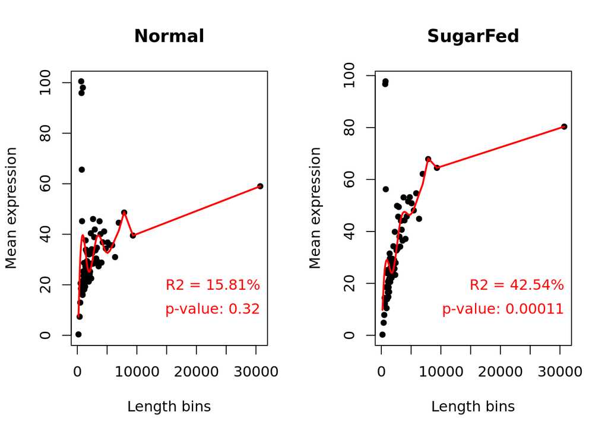

```r
explo.plot(lengthbias_data, samples = NULL, toplot = "global")
```

### GC Content Bias

The “GCbias” plot describes the relationship between the feature GC content and the expression values.

```r
gc_data = dat(noiseq_data, factor = "SampleGroup", type = "GCbias")
```

```
## [1] "Warning: 6285 features with 0 counts in all samples are to be removed for this analysis."
## [1] "GC content bias detection is to be computed for:"
## [1] "Normal"   "SugarFed"
## [1] "Normal"
##
## Call:
## lm(formula = datos[, i] ~ bx)
##
## Residuals:
##     Min      1Q  Median      3Q     Max
## -19.243  -4.387  -0.632   3.720  35.205
##
## Coefficients: (2 not defined because of singularities)
##             Estimate Std. Error t value Pr(>|t|)
## (Intercept)   28.315      9.032   3.135   0.0027 **
## bx1          -20.887     12.773  -1.635   0.1074
## bx2               NA         NA      NA       NA
## bx3         -138.254    140.565  -0.984   0.3294
## bx4            1.414     18.027   0.078   0.9377
## bx5            4.182     11.331   0.369   0.7134
## bx6            7.801     11.376   0.686   0.4956
## bx7          -19.860     13.471  -1.474   0.1458
## bx8          183.593     33.788   5.434 1.14e-06 ***
## bx9         -863.199    184.282  -4.684 1.74e-05 ***
## bx10              NA         NA      NA       NA
## ---
## Signif. codes:  0 '***' 0.001 '**' 0.01 '*' 0.05 '.' 0.1 ' ' 1
##
## Residual standard error: 9.032 on 58 degrees of freedom
## Multiple R-squared:  0.5152, Adjusted R-squared:  0.4484
## F-statistic: 7.705 on 8 and 58 DF,  p-value: 5.669e-07
##
## [1] "SugarFed"
##
## Call:
## lm(formula = datos[, i] ~ bx)
##
## Residuals:
##      Min       1Q   Median       3Q      Max
## -10.1554  -3.5717  -0.8363   3.7198  24.2261
##
## Coefficients: (2 not defined because of singularities)
##             Estimate Std. Error t value Pr(>|t|)
## (Intercept)   15.307      6.268   2.442 0.017665 *
## bx1          -10.970      8.864  -1.238 0.220854
## bx2               NA         NA      NA       NA
## bx3         -166.411     97.544  -1.706 0.093356 .
## bx4            8.614     12.510   0.689 0.493827
## bx5           27.427      7.863   3.488 0.000935 ***
## bx6           16.766      7.895   2.124 0.037967 *
## bx7           -7.458      9.348  -0.798 0.428252
## bx8          113.580     23.447   4.844 9.85e-06 ***
## bx9         -517.087    127.881  -4.044 0.000157 ***
## bx10              NA         NA      NA       NA
## ---
## Signif. codes:  0 '***' 0.001 '**' 0.01 '*' 0.05 '.' 0.1 ' ' 1
##
## Residual standard error: 6.268 on 58 degrees of freedom
## Multiple R-squared:  0.6178, Adjusted R-squared:  0.565
## F-statistic: 11.72 on 8 and 58 DF,  p-value: 9.615e-10
```

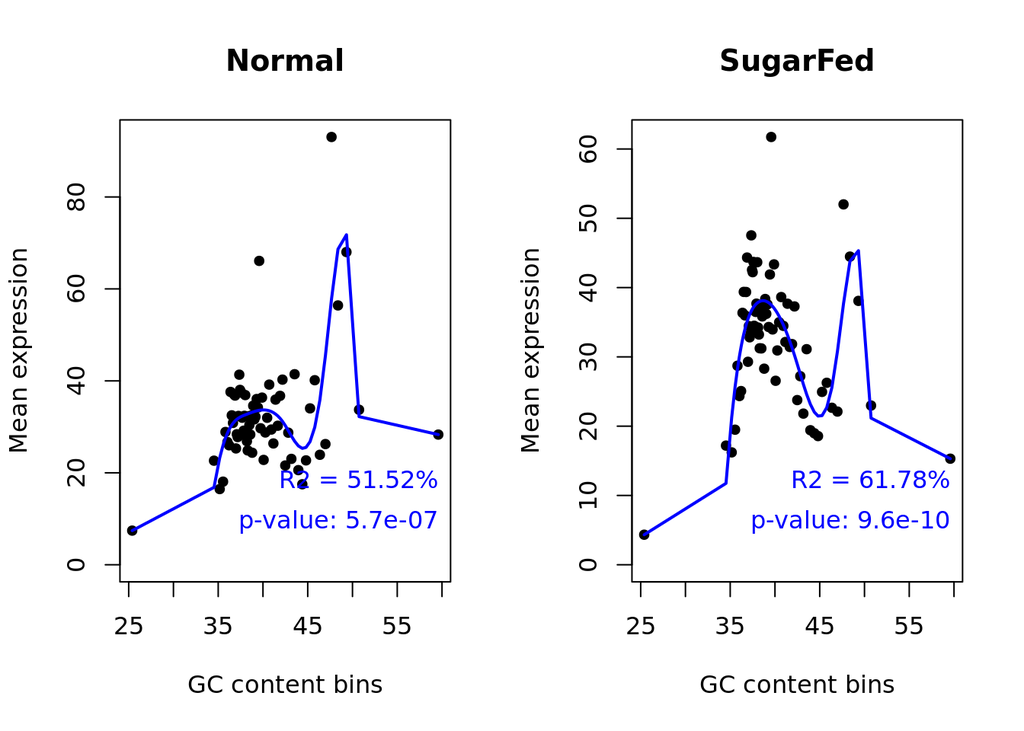

```r
explo.plot(gc_data, samples = NULL, toplot = "global")
```

### Count Stats

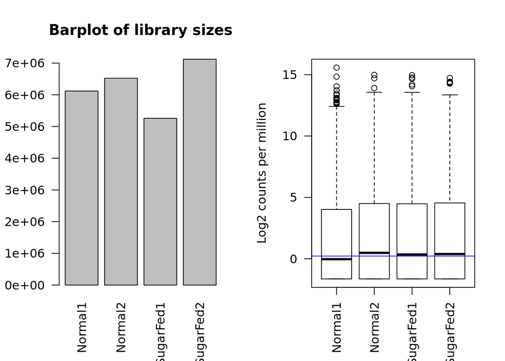

```r
par(mfrow = c(1, 2))
# Check library Sizes
barplot(dge$samples$lib.size, names=colnames(dge), las=2, main="Barplot of library sizes")
abline(h=20e6, lty=2)

# If a sample is really far above or below the blue horizontal line we may need to investigate that sample further
logcounts <- cpm(dge,log=TRUE)
boxplot(logcounts, xlab="", ylab="Log2 counts per million",las=2)
abline(h=median(logcounts), col="blue", main="Boxplots of logCPMs (unnormalised)")
```

### Principal Component Analysis

Visualize if the experimental samples are clustered according to the experimental design or if there is an unwanted source of noise in the data that hampers this clustering is the Principal Component Analysis.

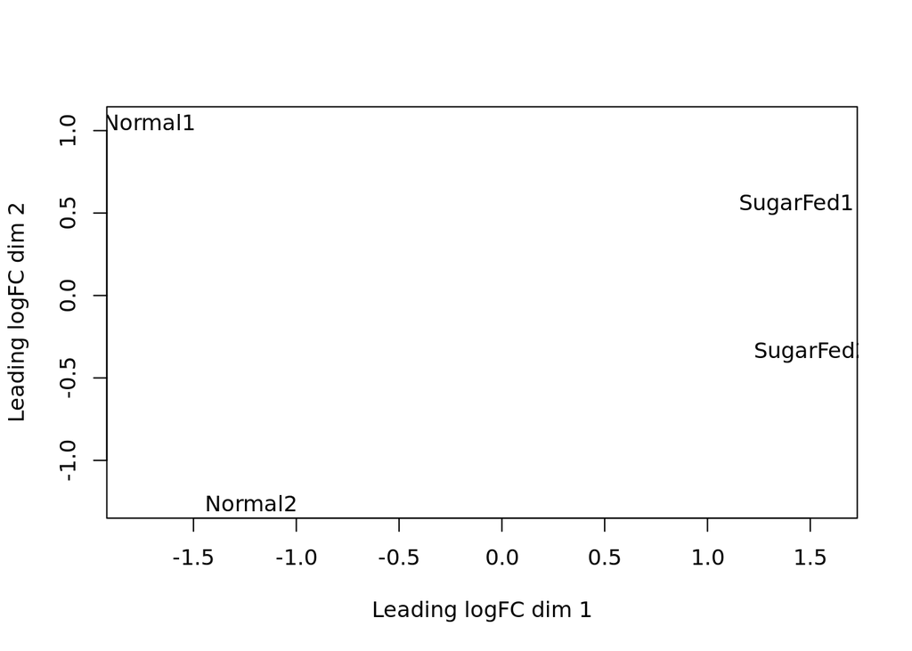

```r
# Principle components analysis
plotMDS(dge)
```

```r
cd_data = dat(noiseq_data, type = "cd", norm = FALSE, refColumn = 1)
```

```
## [1] "Warning: 6285 features with 0 counts in all samples are to be removed for this analysis."
## [1] "Reference sample is: Normal1"
## [1] "Confidence intervals for median of M:"
##           0.83%               99.17%              Diagnostic Test
## Normal2   "0.304992128174522" "0.346015192384478" "FAILED"
## SugarFed1 "0.233411882927334" "0.298004315426638" "FAILED"
## SugarFed2 "0.41043898170338"  "0.485272990538192" "FAILED"
## [1] "Diagnostic test: FAILED. Normalization is required to correct this bias."
```

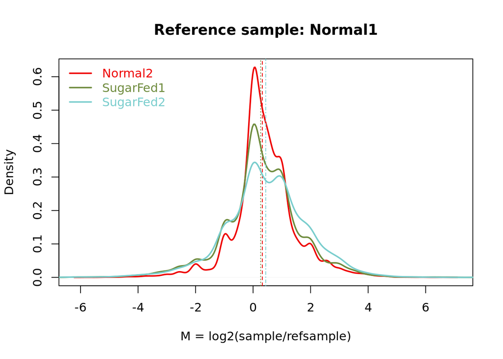

```r
explo.plot(cd_data)
```

# Differential Expression

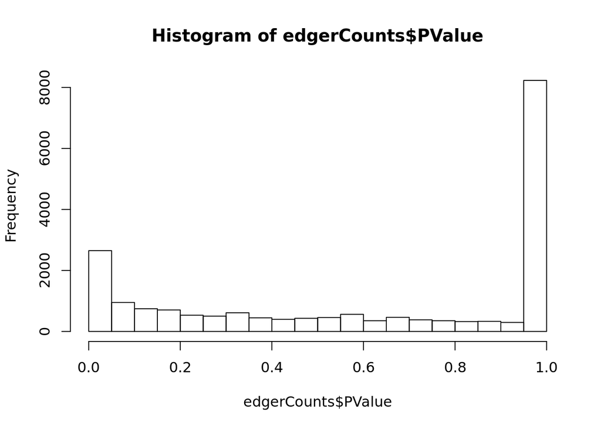

```r
# Histogram of PValue
hist(edgerCounts$PValue)
```

```r
# Summary of Expression Analysis
design <- model.matrix(~ groups)
fit <- glmFit(dge, design)
lrt.BvsL <- glmLRT(fit, coef=2)
results <- as.data.frame(topTags(lrt.BvsL,n = Inf))
summary(de <- decideTestsDGE(lrt.BvsL))
```

```
##        groupsSugarFed
## Down              493
## NotSig          18872
## Up                347
```

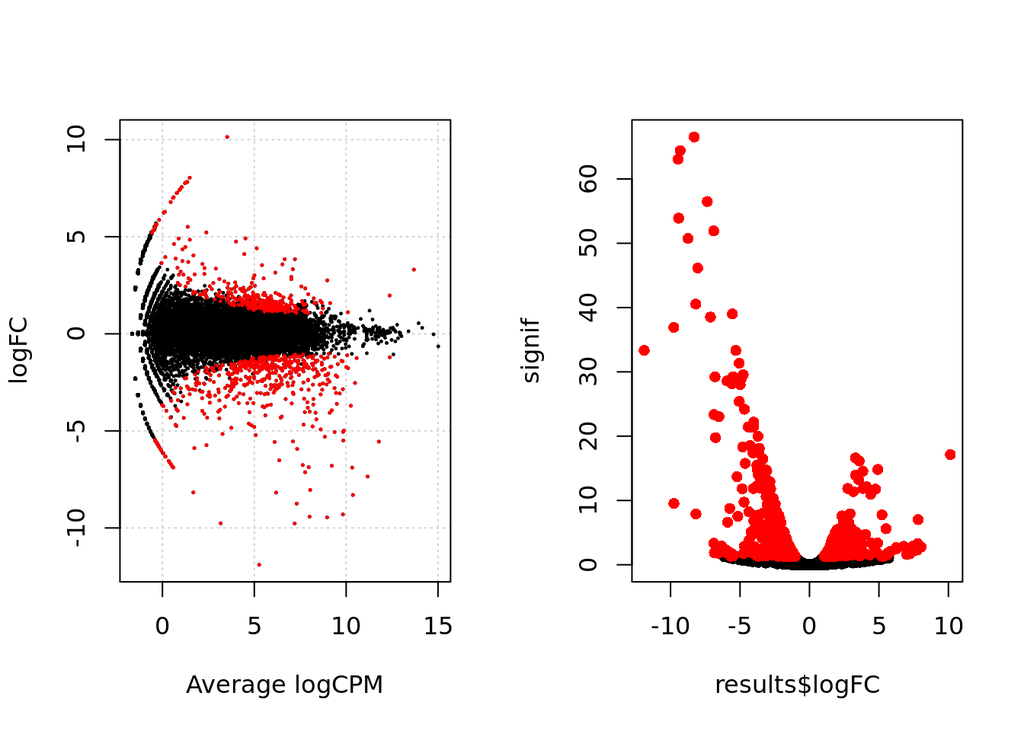

```r
par(mfrow = c(1, 2))
# Log-fold change against log-counts per million with DE genes highlighted
detags <- rownames(dge)[as.logical(de)]
plotSmear(lrt.BvsL, de.tags=detags)

# Volcano plot
signif <- -log10(results$FDR)
plot(results$logFC,signif,pch=16)
points(results[detags,"logFC"],-log10(results[detags,"FDR"]),pch=16,col="red")
```

## Filtering

Filteing the results using a the conditions of pvalue < 0.05 and cpm > 0.5

```r
cpmValues <- cpm(sample_count)
threshCPM <- cpmValues > cpmLimit
keepCPM <- rowSums(threshCPM) >= min(group0numSamples, group1numSamples)

# P-Value
keepPValue <- edgerCounts[,3] < pValueLimit

sample_count_filtered <- sample_count[keepCPM & keepPValue,]

sample_count_filtered_sub <- sample_count_filtered[1:20,]
sample_count_filtered_sub
```

```
##            Normal1 Normal2 SugarFed1 SugarFed2
## AAEL024932       7      11        14         5
## AAEL026536       0       5         8         4
## AAEL024089       0       5         0         4
## AAEL026215     102     176        46        33
## AAEL021190       8       6        12         4
## AAEL009339      60      36        38        71
## AAEL024451       1       4         5         3
## AAEL023380      18      40        17        16
## AAEL023000       2       0         6         5
## AAEL022169      15      10         1         3
## AAEL022013       0      17        42        56
## AAEL020524     309     289       454       709
## AAEL003192      26      35         5        11
## AAEL017258       6      10         1        11
## AAEL007077      24      31        31        15
## AAEL024775       6      29        11        11
## AAEL024516      18      25        11        21
## AAEL025400      10       7        10         8
## AAEL022167       4       2         1         4
## AAEL021447       2      27        17        21
```

```r
sample_filtered_info <- getBM(attributes = c("ensembl_gene_id", "chromosome_name", "gene_biotype", "description", "protein_id", "go_id"), filters = "ensembl_gene_id", values = rownames(sample_count_filtered),  mart = aaegGenes)
```

```
## Batch submitting query [==========================] 100% eta: 0s
```

```r
write.table(sample_filtered_info, file=paste("count/", expName, "_final.tsv", sep=""), sep="\t", col.names=TRUE, quote=FALSE)
```

835 genes left of 19712

### HeatMap

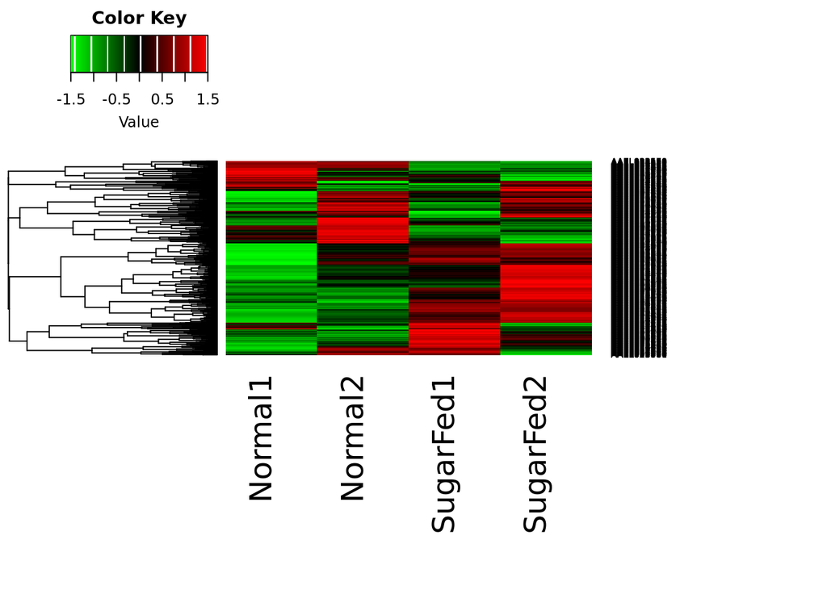

```r
# Read normalized counts

gene = rownames(sample_count_filtered)
vals = as.matrix(sample_count_filtered)

# Adds a little noise to each element
# To avoid the clusteing function failing on zero
# variance datalines.
vals = jitter(vals, factor = 1, amount=0.00001)


# Calculate zscore
score = NULL
for (i in 1:nrow(vals)) {
    row=vals[i,]
    zscore=(row-mean(row))/sd(row)
    score =rbind(score,zscore)
}

row.names(score) = gene
zscore=score

# Generate heatmap
mat = as.matrix(zscore)

colors = colorRampPalette(c("green","black","red"),space="rgb")(256)
heatmap.2(mat,col=colors,density.info="none",trace="none", Colv=FALSE, margins=c(12,12))
```

## References

1. Edger.https://bioconductor.org/packages/release/bioc/html/edgeR.html
2. Noiseq. https://bioconductor.org/packages/release/bioc/html/NOISeq.html
3. Biomart. https://bioconductor.org/packages/release/bioc/html/biomaRt.html